# This is a tutorial for basic python

https://www.learnpython.org/ is a great resource to learn python.

https://towardsdatascience.com/jypyter-notebook-shortcuts-bf0101a98330 contains shortcuts for jupyter. In particular, a, b, m, y,d+d, z, tab, shift+tab,

```python
print("IE4211")
```

```python
print('This course is IE')
print(4211)
```

```python
## Calculation
3^2+5
```

```python
x=1
y=2
z1='abc'
z2='cde'
```

```python
z1+z2
```

```python
x+y
```

## Dictionary

```python
IE4211={'Instructor': 'XL', 'Tutorial':'2H', 'Lecture':'3H'}
IE4211
```

```
{'Instructor': 'XL', 'Tutorial': '2H', 'Lecture': '3H'}
```

```python
IE4212=dict([('Instructor', 'NV'), ('Tutorial','1H'), ('Lecture','2H')])
IE4212
```

```
{'Instructor': 'NV', 'Tutorial': '1H', 'Lecture': '2H'}
```

```python
IE4211['Instructor']
```

```
'XL'
```

```python
#IE4211['Room']  # you can not call a key that does not exist
#IE4211[1] # there is index in dictionary: it is not ordered
print(IE4211.get('Instructor'))
print(IE4211.get('Room'))
```

```
XL
None
```

However, dictrionary can use integer as the key

```python
d={}
d[0]='a'
d[1]='b'
d[2]='c'
d[-1]='d'
d
```

```
{0: 'a', 1: 'b', 2: 'c', -1: 'd'}
```

```python
print(d[1])
print(d[-1])
```

```
b
d
```

Update the dictionary

```python
IE4211['Room']='LT6'
IE4211
```

```
{'Instructor': 'XL', 'Tutorial': '2H', 'Lecture': '3H', 'Room': 'LT6'}
```

```python
IE4212['Tutorial']='3H'
IE4212
```

```
{'Instructor': 'NV', 'Tutorial': '3H', 'Lecture': '2H'}
```

```python
del IE4211['Room']
IE4211
```

```
{'Instructor': 'XL', 'Tutorial': '2H', 'Lecture': '3H'}
```

enumerate the dictionary

```python
for key in IE4211:
    print(key,IE4211[key])
```

```
Instructor XL
Tutorial 2H
Lecture 3H
```

```python
for key,val in IE4211.items():
    print(key,val)
```

```
Instructor XL
Tutorial 2H
Lecture 3H
```

clear the dict

```python
d.clear()
d
```

```
{}
```

## Numpy

NumPy is a library for numerical arrays in Python. To use numpy, we implement the following code

```python
import numpy as np
```

This is suggested way to import numpy. np now is the alias of numpy. You can use np.package to call the packages in numpy library.

```python
x = np.array([1,2,3])
x
```

```
array([1, 2, 3])
```

```python
len(x)
```

```
3
```

We can apply to universal functions on numpy array element-wise.

```python
np.sqrt(x)
```

```
array([1.        , 1.41421356, 1.73205081])
```

```python
np.sin(x)
```

```
array([0.84147098, 0.90929743, 0.14112001])
```

```python
from math import sin
print(sin(1))
# sin(x) # This would incur error
```

```
0.8414709848078965
```

#### Random Numbers, Array, and Matrix

```python
x=np.array([[1,2,3],[4,5,6,7]])
print(x.shape)
len(x)
```

```
(2,)
```

```
2
```

```python
print(np.ones(3))
print(np.ones((2,3)))
np.arange(5)
```

```
[1. 1. 1.]
[[1. 1. 1.]
 [1. 1. 1.]]
```

```
array([0, 1, 2, 3, 4])
```

```python
np.random.seed(2)
print(np.random.rand(3))
print(np.random.randn(2,5))
x=np.random.randint(1,8,3)
y=np.random.randint(1,8,(4,5))
print(x)
print(y)
```

```
[0.4359949  0.02592623 0.54966248]
[[-1.95379641 -1.58688169 -1.07445552 -0.61722311 -1.50100687]
 [ 0.8935898   0.73954567 -1.42356496 -1.11072776  0.08858007]]
[5 3 4]
[[4 7 3 2 3]
 [5 4 6 1 5]
 [7 7 4 2 3]
 [1 5 7 5 3]]
```

Slicing

```python
print(x[0])
print(x[[0,1]])
print(y[0])
print(y[:,2])
print(y[[0,2],2:5])
```

```
5
[5 3]
[4 7 3 2 3]
[3 6 4 7]
[[3 2 3]
 [4 2 3]]
```

change values

```python
y[2,3]=4
y
```

```
array([[4, 7, 3, 2, 3],
       [5, 4, 6, 1, 5],
       [7, 7, 4, 4, 3],
       [1, 5, 7, 5, 3]])
```

Be careful, when you change the value of one array, it might affect another array.

```python
x=np.array([1,2,3])
y=x
print(x)
print(y)
x[1]=4
print(x)
print(y)
```

```
[1 2 3]
[1 2 3]
[1 4 3]
[1 4 3]
```

This is because y becomes a view of x. To avoid this, you can do the followings.

```python
x=np.array([1,2,3])
y=x.copy()
print(x)
print(y)
x[1]=4
print(x)
print(y)
```

```
[1 2 3]
[1 2 3]
[1 4 3]
[1 2 3]
```

In array type *means elementwise multiplication. If you want matrix multiplication, use @ instead of* .

```python
A=np.array([[1,2,3],[4,5,6],[7,8,9]])
x=np.array([[1],[0],[0]])
print(A)
print(x)
print(A*x)
print(A@x)
```

```
[[1 2 3]
 [4 5 6]
 [7 8 9]]
[[1]
 [0]
 [0]]
[[1 2 3]
 [0 0 0]
 [0 0 0]]
[[1]
 [4]
 [7]]
```

### Matplotlib

```python
import matplotlib.pyplot as plt
plt.plot(range(5))
plt.show()
```

[output not shown]

### Pandas

There are two primary data structures in Pandas. The first is the Series object which combines an index and corresponding data values.

```python
import pandas as pd
```

```python
x=pd.Series(index = range(5),data=[1,3,9,11,12])
x
```

```
0     1
1     3
2     9
3    11
4    12
dtype: int64
```

```python
x[1]
```

```
3
```

```python
x=pd.Series(index = ['a','b','d','z','l'],data=[1,3,9,11,12])
print(x[1])
x.a
```

```
3
```

```
1
```

```python
print(x[:3])
print(x['b':])
x[:'z']
x[['a','d']]
```

```
a    1
b    3
d    9
dtype: int64
b     3
d     9
z    11
l    12
dtype: int64
```

```
a    1
d    9
dtype: int64
```

Note that the last slicing include the end point, unlike the case with numeric index.

The second datatype in Pandas is DataFrame

```python
df = pd.DataFrame({'col1': [1,3,11,2], 'col2': [9,23,0,2], 'col3': [10,22,20,12]})
df
```

|  | col1 | col2 | col3 |
| --- | --- | --- | --- |
| 0 | 1 | 9 | 10 |
| 1 | 3 | 23 | 22 |
| 2 | 11 | 0 | 20 |
| 3 | 2 | 2 | 12 |

```python
df['col1']
```

```
0     1
1     3
2    11
3     2
Name: col1, dtype: int64
```

```python
df.iloc[0:2,:2] # Note that this does not include the end point
```

|  | col1 | col2 |
| --- | --- | --- |
| 0 | 1 | 9 |
| 1 | 3 | 23 |

## Newsvendor Example

### Generating samples

```python
ndata=400
feature={}
np.random.seed(2)
feature['Weekday']=np.random.randint(2, size=ndata)
feature['Bignews']=np.random.randint(2, size=ndata)
data=pd.DataFrame(feature)
data.head()
```

|  | Weekday | Bignews |
| --- | --- | --- |
| 0 | 0 | 1 |
| 1 | 1 | 0 |
| 2 | 1 | 0 |
| 3 | 0 | 0 |
| 4 | 0 | 0 |

We assume that the demand $d = 200 - 20 \cdot \text{Weekday} + 100 \cdot \text{Bignews} + 50 \epsilon$, where $\epsilon$ follows a standard normal distribution

```python
np.random.seed(4)
data['Demand'] = 200  - 20 * data['Weekday'] + 100*data['Bignews'] + 50*np.random.standard_normal(400)
```

```python
data.mean()
```

```
Weekday      0.52000
Bignews      0.49000
Demand     242.62891
dtype: float64
```

```python
data.min()
```

```
Weekday     0.000000
Bignews     0.000000
Demand     69.896771
dtype: float64
```

```python
data.max()
```

```
Weekday      1.000000
Bignews      1.000000
Demand     423.829208
dtype: float64
```

```python
data.describe()
```

|  | Weekday | Bignews | Demand |
| --- | --- | --- | --- |
| count | 400.000000 | 400.000000 | 400.000000 |
| mean | 0.520000 | 0.490000 | 242.628910 |
| std | 0.500226 | 0.500526 | 71.935332 |
| min | 0.000000 | 0.000000 | 69.896771 |
| 25% | 0.000000 | 0.000000 | 183.112535 |
| 50% | 1.000000 | 0.000000 | 244.238880 |
| 75% | 1.000000 | 1.000000 | 296.966946 |
| max | 1.000000 | 1.000000 | 423.829208 |

### Visualization

```python
import seaborn as sns
```

The violin plot features a kernel density estimation of the underlying distribution

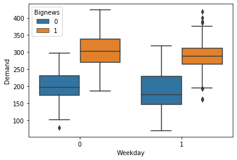

```python
sns.boxplot(x="Weekday", y="Demand", hue="Bignews",data=data)
```

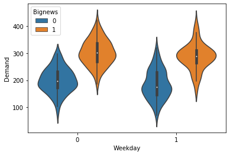

```python
sns.violinplot(x="Weekday", y="Demand", hue="Bignews",data=data)
```

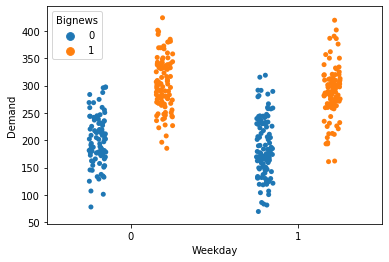

```python
sns.stripplot(x="Weekday", y="Demand", hue="Bignews",data=data,dodge=True)
```

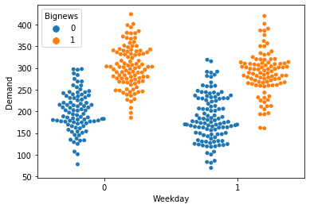

```python
sns.swarmplot(x="Weekday", y="Demand", hue="Bignews",data=data, dodge=True)
```